# Basic Linear Algebra for Deep Learning and Machine Learning Python Tutorial

URL: https://towardsai.net/p/machine-learning/basic-linear-algebra-for-deep-learning-and-machine-learning-ml-python-tutorial-444e23db3e9e

## Implementation of PCA from Scrach

- Implement Covariance Matrix
- Derive Eigenvalues and Eigenvectors
- Analysis from Iris Dataset

```python
import numpy as np
import pylab as plt
import pandas as pd
from sklearn import datasets
import matplotlib.pyplot as plt
from sklearn.preprocessing import StandardScaler
```

```python
load_iris = datasets.load_iris()
iris_df = pd.DataFrame(load_iris.data, columns=[load_iris.feature_names])
iris_df.head()
```

|  | sepal length (cm) | sepal width (cm) | petal length (cm) | petal width (cm) |
| --- | --- | --- | --- | --- |
| 0 | 5.1 | 3.5 | 1.4 | 0.2 |
| 1 | 4.9 | 3.0 | 1.4 | 0.2 |
| 2 | 4.7 | 3.2 | 1.3 | 0.2 |
| 3 | 4.6 | 3.1 | 1.5 | 0.2 |
| 4 | 5.0 | 3.6 | 1.4 | 0.2 |

**Check the Shape of Iris Dataset**

```python
load_iris.data.shape
```

```
(150, 4)
```

**Standardization**

It is always good to standardize the data to keep all feature of data on same scale.

```python
standardized_x = StandardScaler().fit_transform(load_iris.data)
standardized_x[:2]
```

```
array([[-0.90068117,  1.01900435, -1.34022653, -1.3154443 ],
       [-1.14301691, -0.13197948, -1.34022653, -1.3154443 ]])
```

```python
standardized_x.T
```

[output not shown]

[output cut: 145 more lines]

[output not shown]

**Compute Covariance Matrix**

```python
covariance_matrix_x = np.cov(standardized_x.T)
covariance_matrix_x
```

```
array([[ 1.00671141, -0.11835884,  0.87760447,  0.82343066],
       [-0.11835884,  1.00671141, -0.43131554, -0.36858315],
       [ 0.87760447, -0.43131554,  1.00671141,  0.96932762],
       [ 0.82343066, -0.36858315,  0.96932762,  1.00671141]])
```

**Compute Eigenvalues and Eigenvectors from Covariance Matrix**

```python
eigenvalues, eigenvectors = np.linalg.eig(covariance_matrix_x)
```

```python
eigenvalues
```

```
array([2.93808505, 0.9201649 , 0.14774182, 0.02085386])
```

```python
eigenvectors
```

```
array([[ 0.52106591, -0.37741762, -0.71956635,  0.26128628],
       [-0.26934744, -0.92329566,  0.24438178, -0.12350962],
       [ 0.5804131 , -0.02449161,  0.14212637, -0.80144925],
       [ 0.56485654, -0.06694199,  0.63427274,  0.52359713]])
```

**Check variance in Eigenvalues**

```python
total_of_eigenvalues = sum(eigenvalues)
varariance = [(i / total_of_eigenvalues)*100 for i in sorted(eigenvalues, reverse=True)]

varariance
```

```
[72.96244541329987, 22.85076178670177, 3.668921889282871, 0.5178709107154866]
```

**From the above result of variance**

So, here 3rd and 4th Components have very low variannce respectively. These can be dropped. Becasue these components can't add any value.

**Taking 1st and 2nd Components only and Reshaping**

```python
eigenpairs = [(np.abs(eigenvalues[i]), eigenvectors[:,i]) for i in range(len(eigenvalues))]

# Sorting from Higher values to lower value
eigenpairs.sort(key=lambda x: x[0], reverse=True)
eigenpairs
```

```
[(2.9380850501999918,
  array([ 0.52106591, -0.26934744,  0.5804131 ,  0.56485654])),
 (0.9201649041624865,
  array([-0.37741762, -0.92329566, -0.02449161, -0.06694199])),
 (0.14774182104494768,
  array([-0.71956635,  0.24438178,  0.14212637,  0.63427274])),
 (0.02085386217646253,
  array([ 0.26128628, -0.12350962, -0.80144925,  0.52359713]))]
```

```python
matrix_weighing = np.hstack((eigenpairs[0][1].reshape(4,1),
                      eigenpairs[1][1].reshape(4,1)))
matrix_weighing
```

```
array([[ 0.52106591, -0.37741762],
       [-0.26934744, -0.92329566],
       [ 0.5804131 , -0.02449161],
       [ 0.56485654, -0.06694199]])
```

```python
Y = standardized_x.dot(matrix_weighing)
Y
```

```
array([[-2.26470281, -0.4800266 ],
       [-2.08096115,  0.67413356],
       [-2.36422905,  0.34190802],
       [-2.29938422,  0.59739451],
       [-2.38984217, -0.64683538],
       [-2.07563095, -1.48917752],
       [-2.44402884, -0.0476442 ],
       [-2.23284716, -0.22314807],
       [-2.33464048,  1.11532768],
       [-2.18432817,  0.46901356],
       [-2.1663101 , -1.04369065],
       [-2.32613087, -0.13307834],
       [-2.2184509 ,  0.72867617],
       [-2.6331007 ,  0.96150673],
       [-2.1987406 , -1.86005711],
       [-2.26221453, -2.68628449],
       [-2.2075877 , -1.48360936],
       [-2.19034951, -0.48883832],
       [-1.898572  , -1.40501879],
       [-2.34336905, -1.12784938],
       [-1.914323  , -0.40885571],
       [-2.20701284, -0.92412143],
       [-2.7743447 , -0.45834367],
       [-1.81866953, -0.08555853],
       [-2.22716331, -0.13725446],
       [-1.95184633,  0.62561859],
       [-2.05115137, -0.24216355],
       [-2.16857717, -0.52714953],
       [-2.13956345, -0.31321781],
       [-2.26526149,  0.3377319 ],
       [-2.14012214,  0.50454069],
       [-1.83159477, -0.42369507],
       [-2.61494794, -1.79357586],
       [-2.44617739, -2.15072788],
       [-2.10997488,  0.46020184],
       [-2.2078089 ,  0.2061074 ],
       [-2.04514621, -0.66155811],
       [-2.52733191, -0.59229277],
       [-2.42963258,  0.90418004],
       [-2.16971071, -0.26887896],
```

[output cut: 95 more lines]

```
       [ 2.79877045, -0.85680333],
       [ 1.57625591, -1.06858111],
       [ 1.3462921 , -0.42243061],
       [ 0.92482492, -0.0172231 ],
       [ 1.85204505, -0.67612817],
       [ 2.01481043, -0.61388564],
       [ 1.90178409, -0.68957549],
       [ 1.15788161,  0.69886986],
       [ 2.04055823, -0.8675206 ],
       [ 1.9981471 , -1.04916875],
       [ 1.87050329, -0.38696608],
       [ 1.56458048,  0.89668681],
       [ 1.5211705 , -0.26906914],
       [ 1.37278779, -1.01125442],
       [ 0.96065603,  0.02433167]])
```

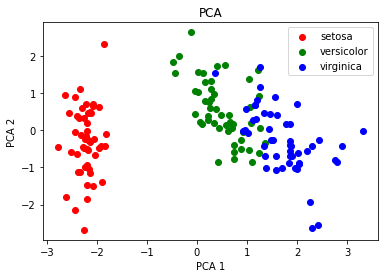

```python
plt.figure()
target_names = load_iris.target_names
y = load_iris.target
for c, i, target_name in zip("rgb", [0, 1, 2], target_names):
    plt.scatter(Y[y==i,0], Y[y==i,1], c=c, label=target_name)

plt.xlabel('PCA 1')
plt.ylabel('PCA 2')
plt.legend()
plt.title('PCA')
plt.show()
```

## Prediction of House Price by using Linear Regression (Linear Equation)

- To understand the usage of Linear Algebra in Linear Regression
- Linear Equation in Linear Regression
- Load Training data of House Price
- Training data of house has only two variables - square_feet, price

```python
# Mount drive
from google.colab import drive
drive.mount('/content/gdrive')
```

```python
import os
path_Data = "//content//gdrive//MyDrive//VTCE AI TUAN//House Price Prediction//"
checkPath = os.path.isdir(path_Data)
checkFile = os.path.isfile(path_Data + "house-prices.csv")
print("The path and file are valid or not :", checkPath, checkFile)
```

```
The path and file are valid or not : True True
```

```python
import pandas as pd
import numpy as np
df = pd.read_csv(path_Data + "house-prices.csv")
df.head()
```

|  | Home | Price | SqFt | Bedrooms | Bathrooms | Offers | Brick | Neighborhood |
| --- | --- | --- | --- | --- | --- | --- | --- | --- |
| 0 | 1 | 114300 | 1790 | 2 | 2 | 2 | No | East |
| 1 | 2 | 114200 | 2030 | 4 | 2 | 3 | No | East |
| 2 | 3 | 114800 | 1740 | 3 | 2 | 1 | No | East |
| 3 | 4 | 94700 | 1980 | 3 | 2 | 3 | No | East |
| 4 | 5 | 119800 | 2130 | 3 | 3 | 3 | No | East |

**Calculating the Mean**

```python
def get_mean(value):
    total = sum(value)
    length = len(value)
    mean = total/length
    return mean
```

**Calculating the Variance**

```python
def get_variance(value):
    mean = get_mean(value)
    mean_difference_square = [pow((item - mean), 2) for item in value]
    variance = sum(mean_difference_square)/float(len(value)-1)
    return variance
```

**Calculating the Covariance**

```python
def get_covariance(value1, value2):
    value1_mean = get_mean(value1)
    value2_mean = get_mean(value2)
    values_size = len(value1)
    covariance = 0.0
    for i in range(0, values_size):
        covariance += (value1[i] - value1_mean) * (value2[i] - value2_mean)

    return covariance / float(values_size - 1)
```

**Implementing a Linear Regression**

```python
def linear_regression(df):

    X = df['SqFt']
    Y = df['Price']
    m = len(X)

    square_feet_mean = get_mean(X)
    price_mean = get_mean(Y)

    #variance of X
    square_feet_variance = get_variance(X)
    price_variance = get_variance(Y)

    covariance_of_price_and_square_feet = get_covariance(X, Y)
    w1 = covariance_of_price_and_square_feet / float(square_feet_variance)
    w0 = price_mean - w1 * square_feet_mean

    # prediction --> Linear Equation
    prediction = w0 + w1 * X

    return prediction
```

**Calling the Linear Regression Method**

```python
prediction = linear_regression(df)
```

```python
df['price (prediction)'] = prediction
df.head()
```

|  | Home | Price | SqFt | Bedrooms | Bathrooms | Offers | Brick | Neighborhood | price (prediction) |
| --- | --- | --- | --- | --- | --- | --- | --- | --- | --- |
| 0 | 1 | 114300 | 1790 | 2 | 2 | 2 | No | East | 115613.979746 |
| 1 | 2 | 114200 | 2030 | 4 | 2 | 3 | No | East | 132468.296124 |
| 2 | 3 | 114800 | 1740 | 3 | 2 | 1 | No | East | 112102.663833 |
| 3 | 4 | 94700 | 1980 | 3 | 2 | 3 | No | East | 128956.980212 |
| 4 | 5 | 119800 | 2130 | 3 | 3 | 3 | No | East | 139490.927948 |

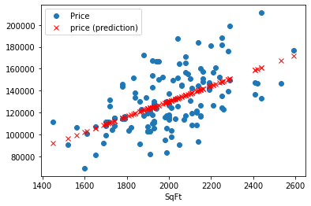

```python
import matplotlib.pyplot as plt
import pandas as pd

ax = plt.gca()
df.plot(x='SqFt', y='Price', style='o',ax=ax)
df.plot(x='SqFt', y='price (prediction)', style='rx',ax=ax)
plt.show()
```